# Explanatory Phase

### A REVIEW OF TOP FIVE AIRLINE PERFORMANCE 2019: MAKING A CASE FOR GREATER EFFICIENCY IN AIRLINES OPERATIONS

## Introduction

The Aviation industry is one of the largest and most active industries moving million of people around thw world. Efficiency and safety are priority in the industry and anything less is not acceptable. There are two factors which are almost unavoidable over the year when aviation performance is disscussed; delays and cancellations.

In this study we will we will work through the performance of the top five airline in USA in 2019 and see area where efficiency in operations need to be greatly improved.

```python
import pandas as pd
import numpy as np
import matplotlib.pyplot as plt
import seaborn as sns
sns.set_style('darkgrid')
plt.style.use('seaborn')
%matplotlib inline
```

```python
pd.set_option('max_columns', None)
pd.set_option('max_rows',500)
pd.set_option('display.width', None)
```

```python
# Read air_time.csv file
air_time = pd.read_csv('air_time1.csv',index_col=False,na_values=' NaN')
```

```python
air_time['AIRLINE']=air_time['OP_UNIQUE_CARRIER'].replace(['9E', 'WN', 'OO', 'AA', 'MQ', 'G4', 'OH', 'B6', 'AS', 'DL', 'YV',
       'EV', 'F9', 'YX', 'UA', 'HA', 'NK'],['Pinnacle Airlines Inc.', 'Southwest Airlines Co.', 'Skywest Airlines Inc.', 'American Airlines Inc.', 'American Eagle Airlines Inc.', 'Allegiant Air', 'Comair Inc.', 'JetBlue Airways', 'Alaska Airlines Inc.', 'Delta Air Lines Inc.', 'Mesa Airlines Inc.',
       'Atlantic Southeast Airlines', 'Frontier Airlines Inc.', 'Midwest Airline, Inc.', 'United Air Lines Inc.', 'Hawaiian Airlines Inc.', 'Spirit Air Lines'])
```

```python
air_time=air_time.loc[:,['FL_DATE', 'MONTH', 'DAY','OP_UNIQUE_CARRIER','AIRLINE', 'ORIGIN', 'ORIGIN_CITY_NAME',
       'DEST', 'DEST_CITY_NAME','DEP_DELAY_NEW', 'ARR_DELAY_NEW',
       'CANCELLED', 'CANCELLATION_CODE', 'AIR_TIME', 'DISTANCE', 'CARRIER_DELAY',
       'WEATHER_DELAY', 'NAS_DELAY', 'SECURITY_DELAY', 'LATE_AIRCRAFT_DELAY', 'FLIGHT STATUS']]
```

```python
air_time2=air_time.loc[air_time["AIRLINE"].isin(['Southwest Airlines Co.','Skywest Airlines Inc.','American Airlines Inc.','Delta Air Lines Inc.','United Air Lines Inc.'])]
```

#### Have ever wondered which of the top five most active airline is the most efficient?

#### Let start with a little premeable.

#### Do you know the top five airline actually made 64% of the flights in 2019.

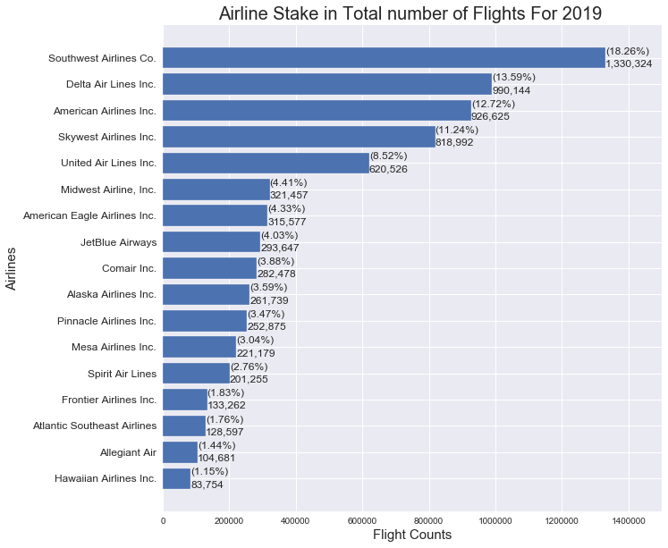

```python
fig,ax=fig,ax=plt.subplots(figsize=(10,10))

y=air_time[air_time['CANCELLED']!=1.0]['AIRLINE'].value_counts( sort=True, ascending=True)

plt.barh(y.index,y)
plt.ylabel("Airlines",fontsize=15)
plt.xlabel("Flight Counts",fontsize=15)
plt.yticks(fontsize=12)
plt.xlim(0,1500000)
plt.title('Airline Stake in Total number of Flights For 2019 ', fontsize=20)

total = y.sum()
for p in ax.patches:
    percent ='({:,.2f}%)'.format(100*p.get_width()/total)
    width, height =p.get_width(),p.get_height()
    x=p.get_x()+width+0.05
    y=p.get_y()+height/1.5
    ax.annotate(percent,(x,y),fontsize=12)
for p in ax.patches:
    percent ='{:,.0f}'.format(p.get_width())
    width, height =p.get_width(),p.get_height()
    x=p.get_x()+width+0.05
    y=p.get_y()+height/12

    ax.annotate(percent,(x,y),fontsize=12)
```

The top five active airlines are;

- Southwest Airlines Co
- Skywest Airlines Inc.
- American Airlines Inc.
- Delta Air Lines Inc.
- United Air Lines Inc.

Now lets take a look at their performance for 2019. Our key focus will be on delays and cancellations as these serve as performance indicators for airlines.

In 2019 these airlines had 78452 cancellations and 1379624 delays.

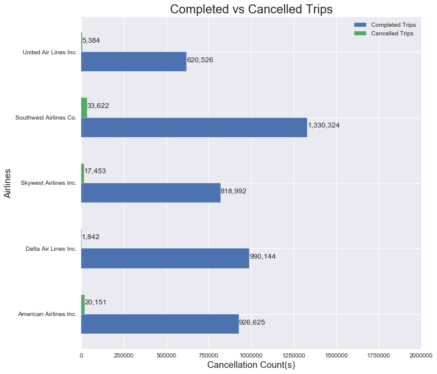

```python
fig,ax=plt.subplots(figsize=(10,10))
a=air_time2[air_time2['CANCELLED']!=1].groupby(['AIRLINE'])['CANCELLED'].value_counts()
b=air_time2[air_time2['CANCELLED']==1].groupby(['AIRLINE'])['CANCELLED'].value_counts()
w=0.3
ind1=np.arange(len(air_time2[air_time2['CANCELLED']==1].groupby(['AIRLINE'])['CANCELLED'].value_counts().index))
ind2 = [i + w for i in ind1]

plt.barh(ind1-w/2,a,w,label='Completed Trips')
plt.barh(ind1+w/2,b,w, label='Cancelled Trips')

plt.yticks([0, 1, 2, 3, 4],['American Airlines Inc.', 'Delta Air Lines Inc.', 'Skywest Airlines Inc.', 'Southwest Airlines Co.', 'United Air Lines Inc.'],rotation=0)

plt.xlim(0,2000000)
plt.ylabel('Airlines',fontsize=15)
plt.xlabel("Cancellation Count(s)",fontsize=15)
plt.legend()
plt.title('Completed vs Cancelled Trips',fontsize=20)
for p in ax.patches:
    percent ='{:,.0f}'.format(p.get_width())
    width, height =p.get_width(),p.get_height()
    x=p.get_x()+width+0.02
    y=p.get_y()+height/2
    ax.annotate(percent,(x,y), fontsize=12)
```

Southwest Airline have the most number of cancelled flights. We would have thought that Delta Airlines been the second most active airline should have cancellation close to SouthWest Airline but it infact has the least number of cancellation. this is really very interest, probably they are doing something different.

```python
##### A very importance question comes to our mind. What are the the reasons for this cancellations?
```

According to the Bureau of Transportation Statistics (https://www.bts.gov/topics/airlines-and-airports/understanding-reporting-causes-flight-delays-and-cancellations) delays reason are in five categories and also same for cancellation except that there is no late Aircraft arrival.

The categories are;

- Air Carrier: The cause of the cancellation or delay was due to circumstances within the airline's control (e.g. maintenance or crew problems, aircraft cleaning, baggage loading, fueling, etc.).
- Extreme Weather: Significant meteorological conditions (actual or forecasted) that, in the judgment of the carrier, delays or prevents the operation of a flight such as tornado, blizzard or hurricane.
- National Aviation System (NAS): Delays and cancellations attributable to the national aviation system that refer to a broad set of conditions, such as non-extreme weather conditions, airport operations, heavy traffic volume, and air traffic control.
- Late-arriving aircraft: A previous flight with same aircraft arrived late, causing the present flight to depart late.
- Security: Delays or cancellations caused by evacuation of a terminal or concourse, re-boarding of aircraft because of security breach, inoperative screening equipment and/or long lines in excess of 29 minutes at screening areas.

[figure not shown]

```python
fig,ax=plt.subplots(figsize=(8,8))

plt.barh(air_time2['CANCELLATION_CODE'].value_counts().index,air_time2['CANCELLATION_CODE'].value_counts())

plt.yticks(['B', 'A', 'C', 'D'],['Weather','Carrier', 'National Air System','Security'], fontsize=12)

plt.xlim(0,60000)
plt.ylabel("Airlines", fontsize=15)
plt.xlabel("Count(s)", fontsize=15)
plt.title('Reason For Flight Cancellation in 2019', fontsize=20)
total = air_time2['CANCELLATION_CODE'].value_counts().sum()
for p in ax.patches:
    percent ='({:,.2f}%)'.format(p.get_width()/total)
    width, height =p.get_width(),p.get_height()
    x=p.get_x()+width+0.02
    y=p.get_y()+height/2.5
    ax.annotate(percent,(x,y),fontsize=12)



for p in ax.patches:
    percent ='{:,.0f}'.format(p.get_width())
    width, height =p.get_width(),p.get_height()
    x=p.get_x()+width+0.02
    y=p.get_y()+height/1.5
    ax.annotate(percent,(x,y),fontsize=12)
```

From the analysis of 2019 flight data, one key reason stands out Weather. Over, 45000 flights were cancelled due to unfavourable weather condition. the true is, can we do anything about this. Certainly NO!!!. We just have to live with severe thhunderstoms, poor visibility, windstorms, hurricanes etc. We came to meet them and they will surely outlive us.

Weather is untouchable, next we look at carrier cancellations which are majorly caused by airlines. Over 30% of the cancellation were as a result of inefficient management of operations by airlines in 2019. Can we do something better

NAS and Security reason are majorly from airport and air traffic control managment. Nobody will compain if there are cancellations due to security issues. Imagine if a terror attack is imminent, nobody will board a plane.

```python
Weather_Cancel = []
NAS_Cancel = []
Carrier_Cancel=[]
Security_Cancel=[]

for i in air_time2['CANCELLATION_CODE']:
    if i=='A':
        Carrier_Cancel.append(i)
    else:
        Carrier_Cancel.append(np.nan)
air_time2.loc[:,'Carrier_Cancel']=Carrier_Cancel


for i in air_time2['CANCELLATION_CODE']:
    if i=='B':
        Weather_Cancel.append(i)
    else:
        Weather_Cancel.append(np.nan)
air_time2.loc[:,'Weather_Cancel']=Weather_Cancel


for i in air_time2['CANCELLATION_CODE']:
    if i=='C':
        NAS_Cancel.append(i)
    else:
        NAS_Cancel.append(np.nan)
air_time2.loc[:,'NAS_Cancel']=NAS_Cancel


for i in air_time2['CANCELLATION_CODE']:
    if i=='D':
        Security_Cancel.append(i)
    else:
        Security_Cancel.append(np.nan)
air_time2.loc[:,'Security_Cancel']=Security_Cancel
```

```python
yz=air_time2.groupby(['AIRLINE'],as_index=False)[['Carrier_Cancel','Weather_Cancel', 'NAS_Cancel','Security_Cancel']].count()
```

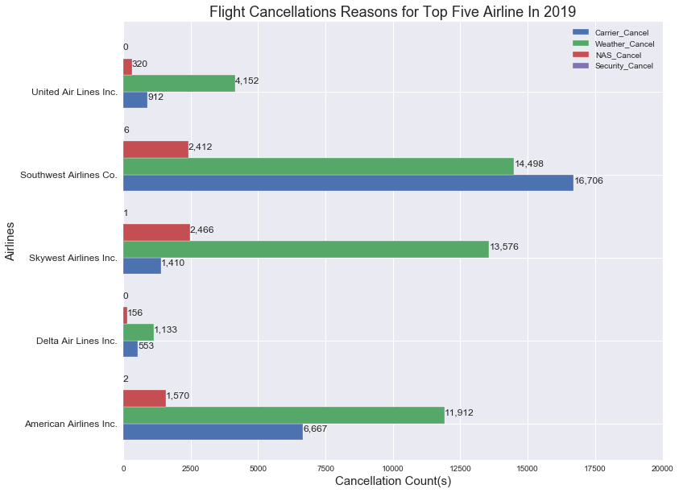

```python
fig,ax=plt.subplots(figsize=(12,10))
w=0.40

ind1=np.arange(0,len(yz['AIRLINE'])*2,2)
#ind2 = [i + w for i in ind1]
#ind3 = [i + w for i in ind2]
#ind4 = [i + w for i in ind3]
plt.barh(ind1-w/2,yz['Carrier_Cancel'],w,label="Carrier_Cancel")
plt.barh(ind1+w/2,yz['Weather_Cancel'],w,label="Weather_Cancel")
plt.barh((ind1+w/2+w),yz['NAS_Cancel'],w,label="NAS_Cancel")
plt.barh((ind1+w/2+2*w),yz['Security_Cancel'],w,label="Security_Cancel")
plt.yticks([0, 2, 4, 6, 8],['American Airlines Inc.', 'Delta Air Lines Inc.', 'Skywest Airlines Inc.', 'Southwest Airlines Co.', 'United Air Lines Inc.'],rotation=0, fontsize=12)
plt.legend()
plt.ylabel('Airlines',fontsize=15)
plt.xlabel("Cancellation Count(s)",fontsize=15)
plt.xlim(0,20000)
plt.title('Flight Cancellations Reasons for Top Five Airline In 2019', fontsize=18)
for p in ax.patches:
    percent ='{:,.0f}'.format(p.get_width())
    width, height =p.get_width(),p.get_height()
    x=p.get_x()+width+0.02
    y=p.get_y()+height/2
    ax.annotate(percent,(x,y), fontsize=12)
```

- Now, have seen that weather is just natural and is untouchable but something need to be done on the over 30% flights cancelled because of poor managenent of operations by airline. The next question is, what reasons are the top five airline giving for cancellation? Is it just weather?
- From the data, we see Southwest Airline has cancellation due to carrier inefficiency higher than weather, this is surely not a good record for the airline although it has the highest number of successful flights. of the top five Delta seens to have the least cancelled flight due to management of operations probably it is doing something special that other airlines need to learn from. it also has the lowest cancelllations due to weather. Two thing come to mind, first it is mostly likely operating from an area where the weather is quite friendly compared to the hubs of other airlines. Secondly, the airline and hub has equipment which can probably help flight operations even in severe weather conditions.
- Now that we have seen how the airlines did interms of flight cancellation for 2019. Let take a closer look at delays in 2019.
- 81 % of the successful flights were on time while 18.9% were delayed. Really, not so bad considering the complexity associated with the operations!!!! But if we need to do better what are the areas we should be looking at improving.

Lets loook at the main reasons for the delays

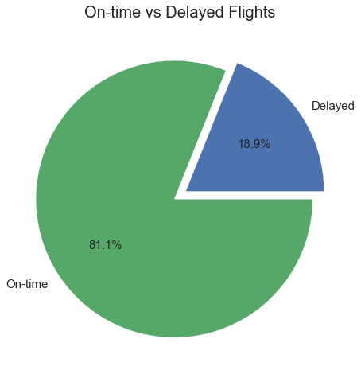

```python
plt.figure(figsize=(8,8))
ix = ['Delayed','On-time']
ii = [1379624,(7287112-1379624)]

plt.pie(x=ii,labels=ix,autopct='%1.1f%%',explode=(0.05,0.05),textprops={'fontsize':15})
plt.title('On-time vs Delayed Flights', fontsize=20)
```

#### Now lets see what are the main reason for the over 18% flight delays.

```python
delay_sum=air_time.loc[:,['CARRIER_DELAY', 'WEATHER_DELAY', 'NAS_DELAY',
       'SECURITY_DELAY', 'LATE_AIRCRAFT_DELAY']].sum().nlargest(5)
idx=air_time.loc[:,['CARRIER_DELAY', 'WEATHER_DELAY', 'NAS_DELAY',
       'SECURITY_DELAY', 'LATE_AIRCRAFT_DELAY']].sum().nlargest(5).index
delay_count=air_time.loc[:,['CARRIER_DELAY', 'WEATHER_DELAY', 'NAS_DELAY',
       'SECURITY_DELAY', 'LATE_AIRCRAFT_DELAY']].count(numeric_only=True).nlargest(5)
idx2=air_time.loc[:,['CARRIER_DELAY', 'WEATHER_DELAY', 'NAS_DELAY',
       'SECURITY_DELAY', 'LATE_AIRCRAFT_DELAY']].count(numeric_only=True).nlargest(5).index
```

[figure not shown]

```python
fig,ax=plt.subplots(figsize=(10,8))
plt.barh(idx2,delay_count)
plt.ylabel("Delay Reasons",fontsize=15)
plt.xlabel("Delay counts",fontsize=15)
plt.xlim(0,1000000)
plt.title('Reason For Flight Delays For Top Five Airlines In 2019', fontsize=18)

for p in ax.patches:
    percent ='({:,.0f})'.format(p.get_width())
    width, height =p.get_width(),p.get_height()
    x=p.get_x()+width+0.02
    y=p.get_y()+height/2
    ax.annotate(percent,(x,y),fontsize=12)
total = delay_count.sum()
for p in ax.patches:
    percent ='({:,.2f}%)'.format(100*p.get_width()/total)
    width, height =p.get_width(),p.get_height()
    x=p.get_x()+width+0.02
    y=p.get_y()+height/1.3
    ax.annotate(percent,(x,y),fontsize=12)
```

- We would have thought weather will dominate in this cas too, NAS, Late Aircraft and Carrier delays contribute almost equally to delayed flight. The NAS delays are majorly related to control of air traffic in and out of the airport. These delays are mostly inevitable and come to play because there is need to control flight movement as several activities which include take off and landing are taking place almost at the same time. A key factor such as how many run way are available for flight operation will play a critical role. If there is a single runway for instance only one activity can take place at a time but where we have several run ways several activities can take place and lots of bottlenecks will be removed. NAS must just do ther jobs to avoid accidents and mishaps. Thats just the truth. Safety of every flight is key.
- Although Late Aircraft seems to be the second highest contributing factor as stated earlier it is totally dependent on other delay reasons. Let look closerly at Carrier delays which resulted in delays of over 650,000 flights. It is a reoccurrng situation as we see in the case of flight delays and obviously a large portion of the late aircraft delays are as a reult of carrier delays. If any airline look to imporve performance i think they need to look at this closely.

Lets look at the delay counts per airline.

```python
Airline_count=air_time2.groupby(['AIRLINE'],as_index=False)[['CARRIER_DELAY', 'WEATHER_DELAY', 'NAS_DELAY',
       'SECURITY_DELAY', 'LATE_AIRCRAFT_DELAY']].count()
```

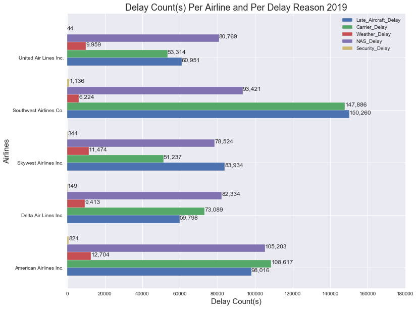

```python
fig,ax=plt.subplots(figsize=(12,10))
w=0.3

ind1=np.arange(0,len(Airline_count['AIRLINE'])*2,2)
#ind2 = [i + w for i in ind1]
#ind3 = [i + w for i in ind2]
#ind4 = [i + w for i in ind3]
plt.barh(ind1-w/2,Airline_count['LATE_AIRCRAFT_DELAY'],w,label="Late_Aircraft_Delay")
plt.barh(ind1+w/2,Airline_count['CARRIER_DELAY'],w,label="Carrier_Delay")
plt.barh(ind1+w/2+w,Airline_count['WEATHER_DELAY'],w,label="Weather_Delay")
plt.barh(ind1+w/2+2*w,Airline_count['NAS_DELAY'],w,label="NAS_Delay")
plt.barh(ind1+w/2+3*w,Airline_count['SECURITY_DELAY'],w,label="Security_Delay")
plt.yticks([0, 2, 4, 6, 8],['American Airlines Inc.', 'Delta Air Lines Inc.', 'Skywest Airlines Inc.', 'Southwest Airlines Co.', 'United Air Lines Inc.'],rotation=0)
plt.legend()
plt.ylabel('Airlines',fontsize=15)
plt.xlabel("Delay Count(s)",fontsize=15)
plt.title('Delay Count(s) Per Airline and Per Delay Reason 2019', fontsize=18)
plt.xlim(0,180000)
for p in ax.patches:
    percent ='{:,.0f}'.format(p.get_width())
    width, height =p.get_width(),p.get_height()
    x=p.get_x()+width+0.02
    y=p.get_y()+height/2
    ax.annotate(percent,(x,y), fontsize=12)
```

Lets look at the length of delays

```python
Airline_mins=air_time2.groupby(['AIRLINE'],as_index=False)[['CARRIER_DELAY', 'WEATHER_DELAY', 'NAS_DELAY',
       'SECURITY_DELAY', 'LATE_AIRCRAFT_DELAY']].sum()
```

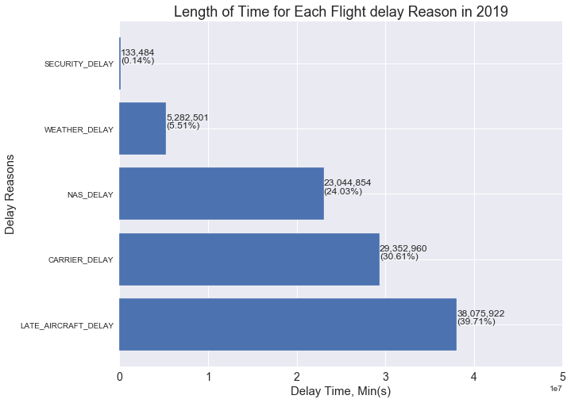

```python
fig,ax=plt.subplots(figsize=(10,8))
plt.barh(idx,delay_sum)
plt.ylabel("Delay Reasons",fontsize=15)
plt.xlabel("Delay Time, Min(s)",fontsize=15)
plt.xlim(0,5e7)
plt.title('Length of Time for Each Flight delay Reason in 2019', fontsize=18)
plt.xticks(fontsize=14)
plt.xticks(fontsize=14)
for p in ax.patches:
    percent ='{:,.0f}'.format(p.get_width())
    width, height =p.get_width(),p.get_height()
    x=p.get_x()+width+0.02
    y=p.get_y()+height/1.5
    ax.annotate(percent,(x,y),fontsize=12)
total = delay_sum.sum()
for p in ax.patches:
    percent ='({:,.2f}%)'.format(100*p.get_width()/total)
    width, height =p.get_width(),p.get_height()
    x=p.get_x()+width+0.02
    y=p.get_y()+height/2
    ax.annotate(percent,(x,y),fontsize=12)
```

- NAS having the highest delays never meant its delays were the longest. Late Aircraft delays are by far the longest delays but as we said earlier Aircraft delays are not independent.
- Carrier delays are actually the second longest but i think they are what need to focus more more in airline operations. No passenger will want to spend severally Minutes at the departure lounge waiting for a flight to board.
- When airline fail to keep strictly to there schedule we not only have carrier delays but also Late aircraft as the most trips are round trips. Late departure means late arrival at the destimation. And those who have been scheduled to travel with the flights will also be delayed and the cycle goes on and on. Now you see airline operations need to be more efficient!!!!

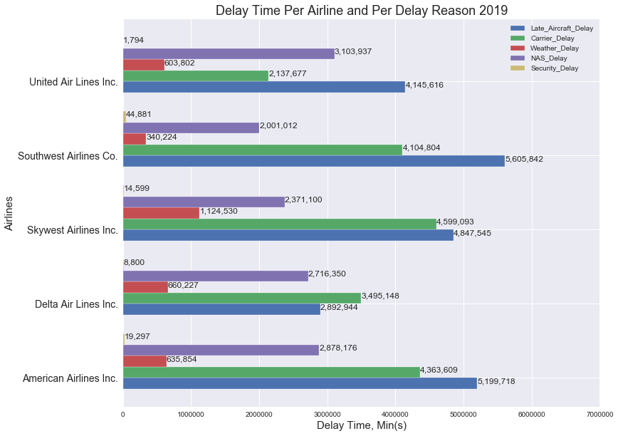

```python
fig,ax=plt.subplots(figsize=(12,10))
w=0.3

ind1=np.arange(0,len(Airline_mins['AIRLINE'])*2,2)
#ind2 = [i + w for i in ind1]
#ind3 = [i + w for i in ind2]
#ind4 = [i + w for i in ind3]
plt.barh(ind1-w/2,Airline_mins['LATE_AIRCRAFT_DELAY'],w,label="Late_Aircraft_Delay")
plt.barh(ind1+w/2,Airline_mins['CARRIER_DELAY'],w,label="Carrier_Delay")
plt.barh(ind1+w/2+w,Airline_mins['WEATHER_DELAY'],w,label="Weather_Delay")
plt.barh(ind1+w/2+2*w,Airline_mins['NAS_DELAY'],w,label="NAS_Delay")
plt.barh(ind1+w/2+3*w,Airline_mins['SECURITY_DELAY'],w,label="Security_Delay")
plt.yticks([0, 2, 4, 6, 8],['American Airlines Inc.', 'Delta Air Lines Inc.', 'Skywest Airlines Inc.', 'Southwest Airlines Co.', 'United Air Lines Inc.'],rotation=0, fontsize=14)
plt.legend()
plt.ylabel('Airlines',fontsize=15)
plt.xlabel("Delay Time, Min(s)",fontsize=15)
plt.title('Delay Time Per Airline and Per Delay Reason 2019', fontsize=18)
plt.xlim(0,7000000)
for p in ax.patches:
    percent ='{:,.0f}'.format(p.get_width())
    width, height =p.get_width(),p.get_height()
    x=p.get_x()+width+0.02
    y=p.get_y()+height/2
    ax.annotate(percent,(x,y), fontsize=12)
```

Could SouthWest Airline be doing more than its capacity. When scheduling and planning airline need to stay within there capacities to avoid unforseen delays.

```python
INDEX=Airline_mins.loc[:,['AIRLINE','CARRIER_DELAY']]

INDEX['DELAY_INDEX']=(INDEX['CARRIER_DELAY']/INDEX['CARRIER_DELAY'].sum())
INDEX.sort_values(by="DELAY_INDEX",inplace=True, ascending=False)
```

To conclude a matrix was developed to rank airline depict how each airline performed interms of delay and cancellation. This matrix is based strictly on Carrier delays or cancellation as this are solely from the airlines. The lower the values the better the performance.

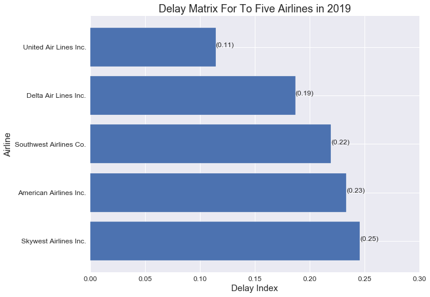

```python
fig,ax=plt.subplots(figsize=(10,8))
plt.barh(INDEX['AIRLINE'],INDEX['DELAY_INDEX'])
plt.ylabel("Airline",fontsize=15)
plt.xlabel("Delay Index",fontsize=15)
plt.xticks(fontsize=12)
plt.yticks(fontsize=12)
plt.title('Delay Matrix For To Five Airlines in 2019', fontsize=18)

plt.xlim(0,0.30)

for p in ax.patches:
    percent ='({:,.2f})'.format(p.get_width())
    width, height =p.get_width(),p.get_height()
    x=p.get_x()+width+0.00001
    y=p.get_y()+height/2
    ax.annotate(percent,(x,y),fontsize=12)
```

The Delays matrix shows that united airline is the best performing in this area but we need to bear in mind that United is actually the least active of the top 5 airlines. Delta airline also showed a very good performance considering it second most active airline.

```python
INDEX1=yz.loc[:,['AIRLINE','Carrier_Cancel']]

INDEX1['Carrier_Cancel'].sum()

INDEX1['CANCELLATION_INDEX']=(INDEX1['Carrier_Cancel']/INDEX1['Carrier_Cancel'].sum())
INDEX1.sort_values(by="CANCELLATION_INDEX",inplace=True,ascending=False)
```

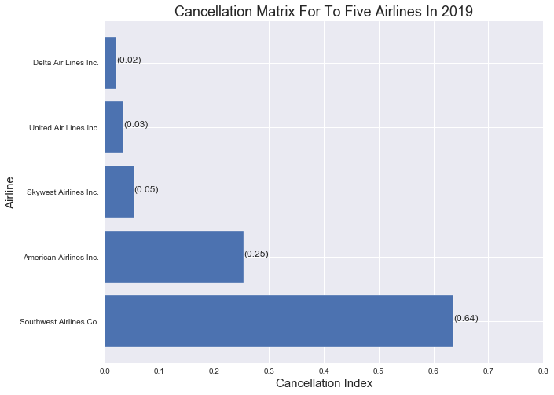

```python
fig,ax=plt.subplots(figsize=(10,8))
plt.barh(INDEX1['AIRLINE'],INDEX1["CANCELLATION_INDEX"])
plt.ylabel("Airline",fontsize=15)
plt.xlabel("Cancellation Index",fontsize=15)
plt.xlim(0,0.8)
plt.title('Cancellation Matrix For To Five Airlines In 2019', fontsize=18)
for p in ax.patches:
    percent ='({:,.2f})'.format(p.get_width())
    width, height =p.get_width(),p.get_height()
    x=p.get_x()+width+0.00001
    y=p.get_y()+height/2
    ax.annotate(percent,(x,y),fontsize=12)
```

From the cancellation matrix, we see that Southwest Airline has the poorest performance based on this matrix while Delta Airline has the best performance.

```python
rank1 = INDEX1.loc[:,['AIRLINE','CANCELLATION_INDEX']]
rank2 = INDEX.loc[:,['AIRLINE','DELAY_INDEX']]

RANK=rank1.merge(rank2,on='AIRLINE')
RANK['RANK']=RANK['CANCELLATION_INDEX']+RANK['DELAY_INDEX']
RANK.sort_values(by='RANK',inplace=True, ascending=False)
```

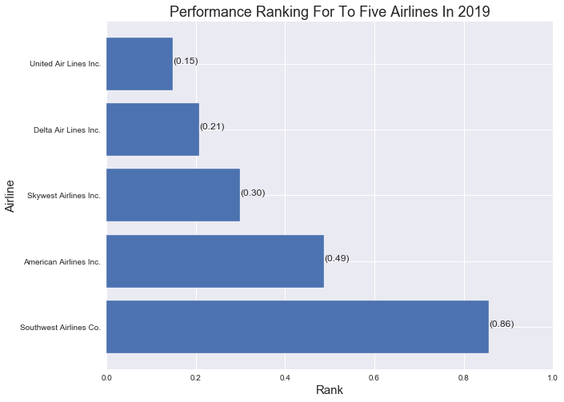

```python
fig,ax=plt.subplots(figsize=(10,8))
plt.barh(RANK['AIRLINE'],RANK["RANK"])
plt.ylabel("Airline",fontsize=15)
plt.xlabel("Rank",fontsize=15)
plt.xlim(0,1 )
plt.title('Performance Ranking For To Five Airlines In 2019',fontsize=18)
for p in ax.patches:
    percent ='({:,.2f})'.format(p.get_width())
    width, height =p.get_width(),p.get_height()
    x=p.get_x()+width+0.00001
    y=p.get_y()+height/2
    ax.annotate(percent,(x,y),fontsize=12)
```

The ranking based on both matrix indicate Southwest airline is the least performing while the United Airline is the best performing. Though it can be said that United is the least active thats why it could be at the top. Delta Airline been the second most active of the top five also has a very good record for 2019.

The Big question is where do we go from here????

There is indeed very great room for improvement in airline operation. The truth is delays and cancellation resulting from weather, security and NAS are almost unavoidable. Safety is key for the aviation industry. Late Aircraft and Carrier delays need to be really looked into in airline operation. More specificially carrier delays and cancellation if reduced to the bearest minimum will surely affect other forms of delays most especially NAS and Late aircraft delays and cancellations.

Keeping to schedule, not going beyond its capacity and putting up the best in terms of technology will go a long way to imporve their performance.

EVERY SECOND MATTERS.